## KSU GIS Day Demo: Make a map in R

#### Tim Assal

In celebration of the Kent State University Department of Geography’s GIS Day, I’ve created a hands-on demo of how to make a map in R.

This is a very basic example does not go into great detail of R or spatial data in R (we don’t have that kind of time!). But if you already know a little something about R and spatial data, this exercise will get you up and running and hopefully serve as a template for your future work.

**Prior to this exercise, create a new RStudio Project in a new working directory, name of your choice. Then in Finder or WindowsExplorer, create two sub directories: “SourceData” and “Figures”. Place all data into the “SourceData” directory**

The data can be accessed on [github](https://github.com/tjassal/Map-with-ggplot) or as a zip file [here](http://timassal.com/wp-content/uploads/2019/11/KSU_data.zip). Special thanks to [MapIt!](https://www.library.kent.edu/map-library/map-it) and Jessica Reese for KSU campus data.

You will need the following packages for this demo: `raster`, `ggplot2`, `sf`, `gridExtra`

If they are not installed on your machine, do so now:

```r
install.packages(c("raster", "ggplot2", "sf", "gridExtra"))
```

```
## Error in contrib.url(repos, "source"): trying to use CRAN without setting a mirror
```

Once installed, they will need to be loaded:

```r
library(raster)
library(ggplot2)
library(sf)
library(gridExtra)
```

### Map 1 - KSU Campus Buildings

First we will load the required shapefiles:

```r
KSU_Campus <- st_read("SourceData/KSU_Boundary.shp")
KSU_Buildings <- st_read("SourceData/KSU_Buildings.shp")
```

*Note: we will not go into details of projections here, but spatial objects used in the same plot must have the same projection. This set of files have the same projection.*

Next we will make the map using ggplot:

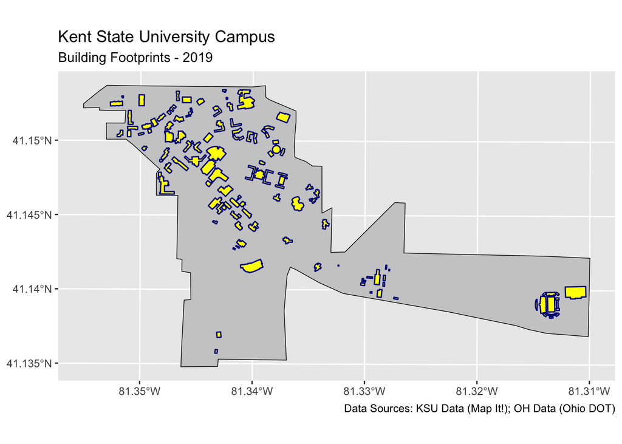

```r
Map1<-ggplot() +
  #load campus boundary first
  geom_sf(data = KSU_Campus, size = 0.25, color = "black", fill = "gray80") +
  #load buildings second - ggplot adds each layer in order, so we want buildings on top
  geom_sf(data = KSU_Buildings, size = 0.5, color = "darkblue", fill = "yellow") +
  coord_sf()+
  #add labels
  labs(title = "Kent State University Campus",
       subtitle = "Building Footprints - 2019",
       caption = "Data Sources: KSU Data (Map It!); OH Data (Ohio DOT)")
Map1 #plot map
```

We can save it to the Figures directory using `ggsave()`:

```r
ggsave("Figures/KSU_Map.jpg", Map1, width=8, height=4, dpi=300) #save map
```

# Map 2 - Kent Vicinity Map

Let’s create a second map so we know where in Ohio Kent is located.

First we’ll load some additional shapefiles:

```r
OH_County <- st_read("SourceData/OH_Counties.shp")
OH_Kent <- st_read("SourceData/Kent_OH_Boundary.shp")
```

Next we will make the map using ggplot:

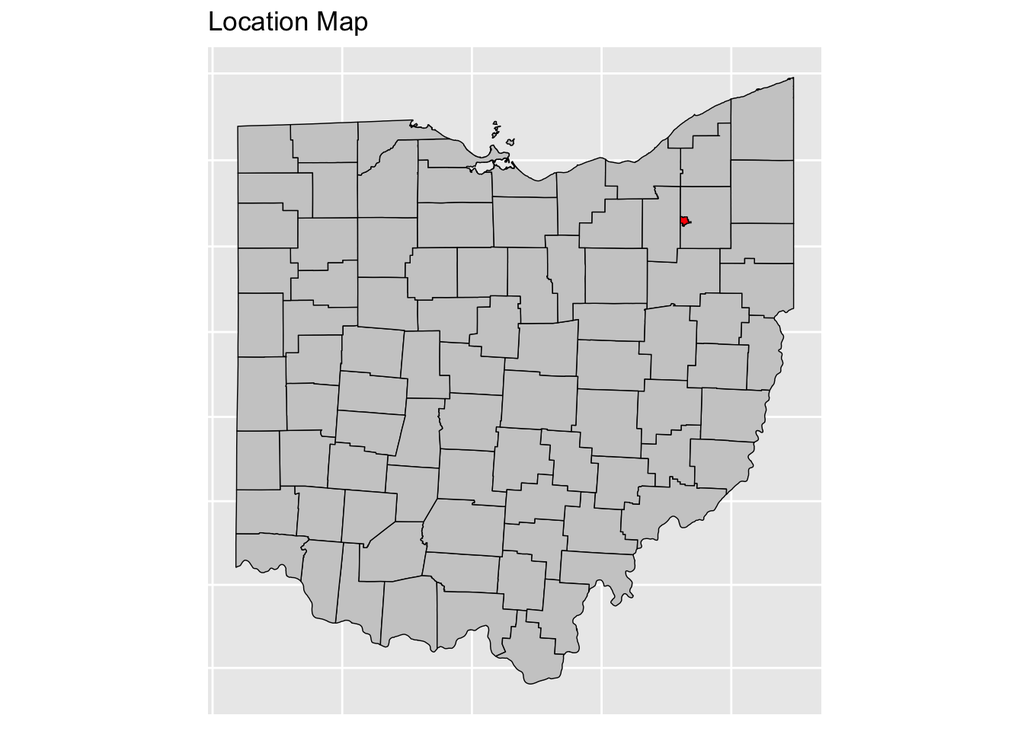

```r
Map2<-ggplot() +
  #load county boundaries first
  geom_sf(data = OH_County, size = 0.25, color = "black", fill = "gray80") +
  #load Kent boundary second - ggplot adds each layer in order
  geom_sf(data = OH_Kent, size = 0.25, color = "black", fill = "red") +
  #here is a different way to add a title
  ggtitle("Location Map") +
  #let's hide the axis ticks and labels since we aren't worried about those details at this scale
  theme(axis.ticks = element_blank(), axis.text.x = element_blank(), axis.text.y=element_blank())
Map2
```

Not bad, but if we show the town of Kent as a polygon it probably won’t scale well. Let’s convert the Kent polygon to a centroid, then we’ll show it on the map as a point.

```r
OH_Kent_Centroid <- st_geometry(st_centroid(OH_Kent))
```

Now we’re ready to make another map using the new centroid:

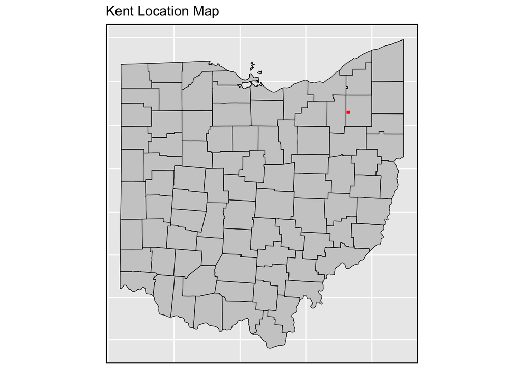

```r
inset.map<-ggplot() +
  #load county boundaries first
  geom_sf(data = OH_County, size = 0.25, color = "black", fill = "gray80") +
  #load Kent centroid; we'll display as a square (shape = 15)
  geom_sf(data = OH_Kent_Centroid, size = 1, color = "red", shape= 15) +
  ggtitle("Kent Location Map") +
  theme(axis.ticks = element_blank(), axis.text.x = element_blank(),
        axis.text.y=element_blank(),
        panel.border = element_rect(colour = "black", fill=NA, size=1))
inset.map
```

This should be much better for scaling the map in the next step.

### Map 3 - Composite Map

Now let’s put the two maps together into a composite map. Since we already wrote the two maps to objects, we can simply call them here and arrange using the `gridExtra` package.

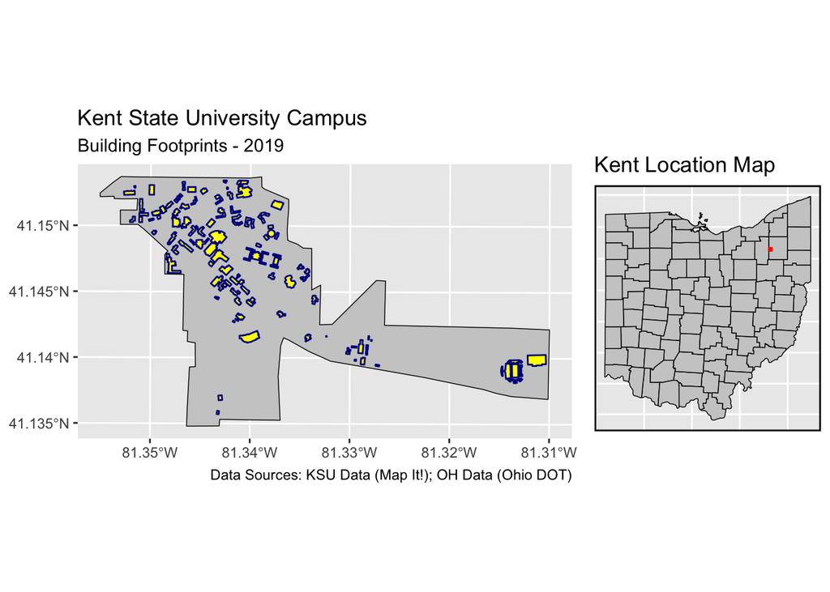

```r
# We'll have two columns, specify the order and the width of each map
composite_map<-grid.arrange(Map1, inset.map, ncol=2, widths=c(7,3))
```

```r
composite_map
```

```r
#save the map
ggsave("Figures/Composite_map.jpg", composite_map, width=8, dpi=300)
```

Now that’s a publication quality map that didn’t take all that much code to create. Hopefully you can use this template to create future maps. Go forth and be spatial!